# The Living SEB Skills Project: A Living Resource for Review and Meta-Analysis of Social, Emotional, and Behavioral Skills

Tommaso Feraco, Margherita Calderan, and Gerardo Pellegrino

Department of General Psychology, University of Padova

# Author Note

Tommaso Feraco https://orcid.org/0000-0002-8920-5330

Margherita Calderan https://orcid.org/0009-0005-5668-5162

Gerardo Pellegrino https://orcid.org/0000-0001-7032-9774

The study was preregistered at https://feracotommaso.github.io/living_SEB_review/preregistration/Preregistration_protocol_livingSEB.pdf Data, code, and materials are available at https://github.com/feracotommaso/living_SEB_review The authors have no conflict of interest to declare The authors received no funding for this study

Correspondence concerning this article should be addressed to Tommaso Feraco, Department of General Psychology, University of Padova, Via Venezia 8, Padova, Veneto 35129, Italy, Email: tommaso.feraco@unipd.it

# Abstract

*Keywords*: meta-analysis; systematic review; living review; socio-emotional skills; open science

# The Living SEB Skills Project: A Living Resource for Review and Meta-Analysis of Social, Emotional, and Behavioral Skills

# Introduction

Social, emotional, and behavioral (SEB) skills–sometimes referred to as “soft skills,” “21st-century skills,” or “social-emotional skills”–are increasingly recognized as essential for success, well-being, and social functioning (Feraco et al., 2023; Heckman & Kautz, 2012). Only in recent years, however, new frameworks have begun to address the field’s long-standing challenges of fragmented conceptualizations and reliance on personality trait measures (Abrahams et al., 2019; Guo et al., 2023; Soto et al., 2022). In particular, Soto and colleagues (2021) proposed the SEB framework and the Behavioral, Emotional, and Social Skills Inventory [BESSI; Soto et al. (2022)], defining and assessing SEB skills as functional capacities, distinct from but complementary to personality traits. This progress has created a novel and timely opportunity to accelerate research on SEB skills starting from a valid, integrative, and common framework.

Nonetheless, psychology, like many other sciences, still faces broad methodological challenges, including the absence of infrastructures that make knowledge cumulative, dynamic, and accessible (F. A. Bosco et al., 2020). Indeed, we usually rely on traditional meta-analyses and systematic reviews, which provide rigorous summaries of evidence but are narrow in scope and static by design. Given the accelerating pace of publication, they often become outdated within just a few years (Elliott et al., 2014; Elliott et al., 2017; Sakaluk et al., 2023). As a result, both old and new promising frameworks–such as SEB skills–risk fragmentation or premature stagnation if evidence cannot be continually updated and integrated.

To address this challenge, the concept of *living systematic reviews* has been developed to propose that reviews and meta-analyses are continually updated as new studies are published (Elliott et al., 2017). However, their adoption in psychology has been limited, and no living meta-analysis has yet been devoted to SEB skills. This gap is particularly striking given that SEB skills research is a young and rapidly growing field, precisely where static reviews are not conducted and selective reporting might prove particularly impacting, given potential conflicts of interests toward the initial expansion and adoption of the model.

In light of these general limitations, the present article introduces the *Living SEB Skills Project*: a research infrastructure for cumulative SEB skills science. This initiative integrates (a) ongoing systematic literature searches, (b) centralized open databases of coded study information and effect sizes, and (c) a user-friendly web application for customized reviews and meta-analyses. Together, these tools provide researchers, reviewers, editors, and practitioners with continually updated, openly accessible evidence on SEB skills.

To illustrate the substantive and theoretical utility of the *Living SEB Skills Project* and its tools, we also present direct analyses of the current database that test predictive and incremental validity of SEB skills for academic achievement: a multilevel meta-analysis of the associations between SEB domains and academic achievement, and two meta-analytic structural equation models testing incremental validity of each SEB skill beyond personality traits and beyond the other SEB skills included in the model.

Our overarching goal is to prevent SEB skills research from repeating the familiar cycle of selective reporting, fragmentation, and stagnation of many different fields in psychology.

## Social, Emotional, and Behavioral Skills

The *Living SEB Skills Project* is grounded in the conceptualization of SEB skills proposed by Soto and colleagues (2021; 2022). In this framework, SEB skills are defined as the functional capacities individuals can draw upon to build relationships, pursue goals, think creatively, and regulate their emotions. After reviewing the various theoretical models of skills presented in the literature, Soto and colleagues (2022) identified 32 skills and organized them into five broad domains derived from the Big Five model of personality traits (McCrae & Costa, 1989). Importantly, skills are clearly distinguished from personality traits: whereas traits capture enduring patterns of thoughts, feelings, and behaviors, skills reflect what individuals *can do when required*. For example, a person may typically avoid public speaking (a trait tendency) but still be able to deliver an effective presentation when needed (a skill capacity).

The five SEB skills domains, paralleling the Big Five personality traits, comprise:

- Innovation skills, including the capacities used to process and engage with novel ideas and experiences (linked to the openness personality trait).
- Self-management skills, including the capacities used to manage and complete goal-related tasks (linked to the conscientiousness personality trait).
- Social engagement skills, including the capacities used to actively and efficiently engage and communicate with other people (linked to the extraversion personality trait).
- Cooperation skills, including the capacities used to maintain positive social relationships (linked to the agreeableness personality trait).
- Emotional resilience skills, including the capacities used to regulate emotions and moods (linked to the emotional stability personality trait).

To assess these skills, the Behavioral, Emotional, and Social Skills Inventory (BESSI) was developed utilizing items that are phrased to measure capacities (“How well can you…?”) rather than frequencies (“How often do you…?”) and effectively distinguishing skills from traits (Soto et al., 2022). Indeed, SEB skills show both overlap with, and incremental validity beyond, personality traits (Chen et al., 2024; Feraco et al., 2024; Lechner et al., 2022; Postigo et al., 2024; Soto et al., 2023; Soto et al., 2024; Yoon et al., 2024). Additionally, skills–traits mismatches (e.g., high extraversion but low social engagement skills) predict unique outcomes for adolescents (Ringwald et al., 2025). For instance, students whose skills exceeded their traits (i.e., individuals who do not typically engage in a behavior but are nonetheless proficient at it) reported better outcomes than those whose traits exceeded their skills (i.e., individuals who often engage in a behavior but are not particularly skilled at it). Evidence also suggests that skills and traits follow similar but distinct developmental trajectories (Feraco & Meneghetti, 2023; Napolitano et al., 2025), and laypeople perceive them as meaningfully different constructs (Feraco, Hudson, et al., 2025).

Despite this progress, studies adopting the SEB skills framework already display considerable heterogeneity, making them difficult to synthesize. For instance, some studies have sought to expand the framework’s nomological network by considering all SEB facets and domains (Postigo et al., 2024; Soto et al., 2024), whereas others have focused on specific skill facets (Breil et al., 2022; Collie & Ryan, 2025). In such a rapidly developing area, relying on static reviews or individual literature searches risks selective citation, cherry-picking of results, and conceptual fragmentation. To mitigate these risks, we propose a living and cumulative approach to synthesizing SEB research.

## Introducing Living Research Infrastructure for Cumulative Science

Current approaches to theoretical and quantitative synthesis of scientific materials mainly rely on meta-analyses and systematic reviews. However, especially in view of the steeply increasing number of publications, both of them become outdated soon, requiring recurring updates. These are often conducted by different authors and, even if data sharing is becoming common nowadays, building on previous meta-analysis often requires running a new database search or coding additional information leading new authors to run meta-analysis (even on the same effect) from scratch. This results in duplicate screening of materials, loss of resources and time, and potentially increased human error (F. Bosco et al., 2015; Elliott et al., 2017).

To overcome these issues, living meta-analysis and databases are now appearing in the literature, especially for medical studies, clinical trials, and interventions (F. Bosco et al., 2015; Cuijpers et al., 2022; Elliott et al., 2014; Howard & Slemp, 2025; Sakaluk et al., 2023; Spadaro et al., 2022). These approaches usually maintain a continually updated database of eligible studies, alongside transparent procedures for incorporating new evidence. They are particularly beneficial for rapidly evolving fields where timely integration of knowledge is critical, as showed by the many living reviews appeared during COVID-19. Nonetheless, these systems usually rely on users to upload new data or remain limited to very narrow topics or effects. An exception is the massive attempt of semi-automated data collection and synthesis represented by the *metaBUS* project (F. A. Bosco et al., 2020) in which correlation matrices of published studies in Organizational Psychology are systematically integrated into a common database for rapid integration, description, and synthesis. With our proposal, we aim to contribute to these efforts introducing a living platform for review and meta-analysis on SEB skills that overcome some previous limitations by (a) covering a new and comprehensive research framework, similarly to what Howard and colleagues proposed (2025), and (b) making the database update systematic, thus following Preferred Reporting Items for Systematic Reviews and Meta-Analysis guidelines [PRISMA; Moher et al. (2015)] repeatedly across time.

Providing a similar tool would speed up and facilitate researchers’ literature search, support a standardized and evidence-based understanding of the literature, and inform future research. Given the recency of the framework, fragmentation risks, and rapid expansion of this new research area, SEB skills represent an ideal case for introducing a living review system.

## Rationale, aims, and hypotheses

Accordingly, the *Living SEB Skills Project* has three main aims:

- **Review aim:** To provide a living and organized map of SEB skills literature, freely accessible and filterable by topic, population (e.g., adolescents or adults), or publication years.
- **Meta-analytic aim:** To offer pre-processed database to continually synthesize associations between SEB skills and all other constructs and variables measured alongside, starting with cross-sectional correlations but expandable to longitudinal and experimental data.
- **Open Science aim:** To provide, together with open materials, the Living SEB App, an open-access, interactive platform that integrates the database and analysis tools, enabling replication, rapid evidence checks, preregistration support, and community contributions.

To demonstrate feasibility of the project and show its potential for theory building and testing, we also test the predictive and incremental validity of SEB skills for academic achievement running multiple meta-analysis with the data produced by the *Living SEB Skills Project* to date. In particular, we use both multilevel meta-analysis of correlations and meta-analytic structural equation modeling (MASEM)..

# Methods

## Transparency and Openness

All past and future procedures for this project are preregistered and publicly available on [GitHub](https://feracotommaso.github.io/living_SEB_review/preregistration/Preregistration_protocol_livingSEB.pdf) . The repository (https://github.com/feracotommaso/living_SEB_review) also hosts all materials, data, and R code used in this article. All materials are also available on Zenodo (https://doi.org/10.5281/zenodo.19101246), where snapshots of monthly Git releases will be identified with specific DOIs for future use (e.g., for studies that need to reference the exact version of the Living SEB Skills Project used in their analyses). Analyses will strictly follow the preregistration unless otherwise noted. The systematic search and review is conducted according to the PRISMA guidelines (Moher et al., 2015).

## Search Strategy

The comprehensive literature search was conducted and will be conducted monthly on two electronic databases: Web of Science (WOS) and Scopus. To balance comprehensiveness with feasibility, we adopted a citation-chaining strategy (Hirt et al., 2023): all papers citing one or more seminal theoretical or measurement works on SEB skills were (and will be) retrieved. This strategy ensures that all studies using the SEB skills framework or BESSI measures are captured while reducing noise from unrelated keyword-based searches. While efficient, this approach may overlook studies that deviate from standard research guidelines and measure or reference SEB skills without citing either the seminal works or the validation and measurement papers. To mitigate this risk, the database is continuously updated, and authors are encouraged to submit missing studies (see guidelines for submission on GitHub).

The initial reference papers included in the search string cover theoretical basis (Soto et al., 2021), original measurement papers (Soto et al., 2022), their cultural and language adaptations (Feraco et al., 2024; Lechner et al., 2022; Postigo et al., 2024), and shorter versions of the BESSI (Sewell et al., 2024). For readability, the full search string is available in the preregistration protocol only and will be updated when new measurement or basic theoretical papers are published.

## Study Eligibility Criteria

Studies are considered for inclusion in the database if their main focus is SEB skills and/or they collect data using BESSI-based measures. Works are excluded if they cite the reference papers but do not focus on the SEB skills framework and do not use any BESSI measures. For example, articles mentioning the SEB skills framework but assessing skills derived from other frameworks, such as the OECD (OECD, 2021) or CASEL(Payton et al., 2000), are not considered for inclusion. Similarly, studies focusing solely on other constructs are excluded even if they cite the reference papers. However, if a study examines a different construct but also collects ancillary data using the BESSI, it is included in the meta-analysis. Publications are also excluded if they are published as theses, conference abstracts, or books. Data publications are included if the data are not already included in an indexed study.

To be included in the quantitative database, studies also have to:

1. Be written in a language comprehensible to the authors (i.e., English, Italian, and Spanish);
2. Include original quantitative data using a validated or translated BESSI-based measure;
3. Report correlations, raw data, or provide correlations/data after authors’ request;
4. Include original data not already reported in other included studies.

Contrarily, a study is excluded from the quantitative database for meta-analysis if:

1. Data are duplicated across publications;
2. Measures are not validated or outside the SEB skills and BESSI framework;
3. The study does not report correlations at baseline or data could not be reduced to correlations.

### Coding Procedures

For each included study, the following information was systematically coded:

- *Bibliographic metadata*: DOI, title, authors, journal, year, and download date.
- *Paper, sample, and matrix IDs*: The unique progressive identifiers of each paper, sample, and correlation matrix.
- *Exclusion reason:* both for the review and the meta-analysis.
- *Review topics*: The main topics covered by the study.
- *Open data*: Whether data is openly available or not and the link to the data.
- *Study design*: Whether the study is cross-sectional, longitudinal, or experimental.
- *Country*: Country of origin of the participants. In case participants from multiple countries were included in the same sample, the sample was coded as “mixed”.
- *Gender*: The percentage of females.
- *Age*: The mean age of the sample.
- *Sample size*: The sample size of each population on which correlations were estimated.
- *Age category:* An additional category was added to distinguish between samples of primary school students, secondary school students, young adults (university students or younger than 30), adults (younger than 55) older adults (55 or older). Adults was used also if the study included participants of all ages or between 19 and 55 years old.
- *Clinical population*: Samples are divided between clinical populations and non-clinical populations. In case a clinical population was included, we specify the diagnosis.
- *SEB* *measure*: BESSI 192, 96, 45, 20 or other versions.
- *Measure type*: Long (if it measures facets) or short (if it only measures domains).
- *Trait framework*: In case personality traits are measured, whether they are measured with a BF measure or an HEXACO measure.
- *Effect sizes*: The entire Pearson’s correlations matrices among all study variables are extracted from the papers as measure of effect size. For papers including repeated measurements on the same sample (e.g., longitudinal studies, intervention studies with pre/post assessment), the correlations matrix is extracted only from the first data collection.
- *Non-SEB indicators*. All measures, outcomes, and correlates are manually classified within the names of the correlation matrix. A codebook with all measures coded is available on the GitHub page of the project allowing categorizations of variables in specific and broader categories.

## Updating Procedures and Timeline

We currently expect to provide hand-processed monthly updates of the database until 2030, while working on expanding the collaborative efforts from the community and integrating semi-automized processes for the future.

## The Living SEB App

In parallel with the database, we developed the *Living SEB App*, a Shiny-based web platform that provides direct access to the database and analytic tools. The app enables users to:

- Search and filter literature by topic, population, or design;
- Run meta-analyses of SEB skills associations with outcomes, using multilevel models;
- Conduct meta-analytic structural equation modeling (MASEM) for incremental validity analyses or for estimating more complex correlation matrices;
- Download datasets and correlation matrices for further analyses;
- Generate reproducible reports to support preregistration, peer review, and editorial decision-making.

The app is hosted openly and mirrored on GitHub to ensure sustainability and version control. While designed to lower barriers for non-technical users, the raw datasets and R code remain freely available for advanced or customized analyses.

The *Living SEB App* is available at https://feracotommaso.github.io/living_SEB_review/shiny-app.html.

# Results

Given the adaptive nature of the *Living SEB Skills Project*, the current results apply to the current database (March 2026: https://doi.org/10.5281/zenodo.19101247). An overview of the database and updated results of the same analyses on the latest release, together with additional analyses, are available as a blog post at: https://feracotommaso.github.io/living_SEB_review/paper/livingSEBresults.html.

## Database Overview

Across these studies, a total of 17664 correlation coefficients were coded, representing 6074 unique pairwise associations. Of these, 14491 correlations (3935 unique associations) involved at least one SEB domain or facet measured with a BESSI instrument. This provides the foundation for both the living database and the illustrative analyses reported below.

A continuously updated summary of descriptive statistics is available online at https://feracotommaso.github.io/living_SEB_review/paper/livingSEBresults.html.

## Multilevel Meta-analysis of Correlations

As a demonstration of the project’s multilevel meta-analytic pipeline, we tested the associations between the five SEB skill domains and academic achievement. Following preregistered procedures, a three-level random-effects model was used, with effects nested within samples and studies. In line with Borenstein and colleagues (2021), Fisher’s *z* transformations were applied and then back-transformed to Pearson’s *r* for interpretation. The metafor package was used for the meta-analysis (Viechtbauer, 2010).

A total of 50 effect sizes from 9 studies and 10 samples were included. For each SEB domain, the median available sample size was 796 (minimum sample size = 319; maximum sample size = 5075).

The *Q* test for heterogeneity shows that there is significant heterogeneity across studies, with the standard deviation of the effects ranging between 0.06 and 0.11.

## Meta-analytic Structural Equation Modeling

To illustrate the use of meta-analytic structural equation modeling within the *Living SEB Skills Project*, we tested whether each SEB skill predicted academic achievement beyond their corresponding Big Five traits and other SEB skills. First, using the first stage of the two-staged structural equation modelling (TSSEM) procedure, we synthesized the bivariate correlations among all variables using a random-effects model. This yields a pooled meta-analytic correlation matrix of each pairwise association between all the Big Five traits, the five SEB domains, and academic achievement that accounts for sampling error and between-study heterogeneity (Cheung, 2015).

Next, we applied one-stage meta-analytic structural equation modelling (OSMASEM) (Jak & Cheung, 2020). OSMASEM estimates the structural model in a single step by fitting a structural equation model directly to the meta-analytic covariance structure while simultaneously modeling sampling variance and between-study heterogeneity. This approach allows regression paths to be estimated within an SEM framework using the full pooled covariance matrix. Using OSMASEM, we estimated five saturated regression models, each including one SEB domain and its matched Big Five trait as predictors of academic achievement. Additionally, a multiple regression model was estimated including all five SEB domains as predictors of academic achievement.

The metaSEM (Cheung, 2024) and lavaan (Rosseel, 2012) R packages were used for these analysis and the open code of the webMASEM app (Jak et al., 2021) was used to guide coding of the *Living SEB App* section for MASEM.

MASEM analyses were based on varying number of effect sizes per pairwise correlation (i.e., different correlation matrices), with the minimum available effects per correlation being 3 and the maximum being 25. As a consequence, also sample sizes and precision differed, with the minimum being 2712 (i.e., correlations between personality traits and academic achievement) and the maximum being 23321 (i.e., correlations between SEB domains). Correlation matrices were taken from 26 samples included in 19 different studies.

Given the low number of studies available for some variables, we set between-study variance to zero and estimated a common effect across studies. This approach avoids attempting to estimate random‐effects components that would be unstable or poorly identified in sparse conditions.

### Incremental Validity Beyond the Big Five

These results confirm that SEB skills, as measured by the BESSI questionnaires, differ from the Big Five in terms of predictive validity, with Innovation, Self-management, and Social engagement having higher predictive power than Openness, Conscientiousness, and Extraversion.

## Incremental Validity Between SEB Skills

These results confirm Self-management as the most predictive skill for academic achievement. However, the results also show a small but negative effect of Emotional resilience skills, potentially due to multicollinearity or suppression effects.

## Reproducibility via the Living SEB App

All analyses can be reproduced in the Meta-analysis and MetaSEM modules of the Living SEB App. Users can select specific subsets of studies, download data and R code, and generate updated reports. In line with this idea, an updated report of these analyses is published monthly at https://feracotommaso.github.io/living_SEB_review/paper/livingSEBresults.html as part of the project.

# Discussion

As exemplified in these analyses, the Living SEB Skills Project provides the necessary tools and data for responding cross-sectional research questions and synthesizing the available evidence using meta-analysis. However, different uses can be made of this data and of the Living SEB App.

## Use and Utility the Open Data and the *Living SEB App*

First of all, the Living SEB Project materials and the app can be used to synthesize the literature based on the SEB skills framework using meta-analytic procedures and speeding up literature search with useful tools to find all the SEB skills papers covering a specific topic or using/measuring a specific variable. However, considering the limitations detailed below, the results and the reports that can be obtained using the Living SEB App should not be considered as publication-ready meta-analysis, which would require additional steps and integration (e.g., risk of bias analysis, tests for publication bias, moderator analysis, tailored modelling approaches). For this reason, we suggest using the Living SEB App and the open data available for rapid synthesis only or to inform hypotheses and Bayesian priors for future studies (e.g., the meta-analytical estimates and confidence intervals obtained might be directly used as quantitative priors). Additionally, the reports downloaded from the app (or the data downloaded together with users’ R code) could be directly used to support preregistrations and, for instance, uploaded on the Open Science Framework (OSF) or other preferred platforms as evidence for the justification of the effect sizes used in power analyses. On the other hand, reviewers and editors may benefit from this project for their work. Indeed, they can rapidly check whether authors’ assertions correspond to up-to-date evidence within the SEB framework, whether the necessary literature has been cited or whether the theoretical introduction and hypotheses are based on the full breadth of evidence or on selected papers. Reports and results obtained from the app could thus be used by reviewers and editors to support their suggestions, without conducting long literature reviews.

Beyond its practical utility, the *Living SEB Skills Project* has broader implications for the theoretical development of SEB skills research and psychology more generally. By maintaining a continuously updated, transparent synthesis of findings, the project helps guard against selective citations, cherry-picking, and conceptual fragmentation that have historically slowed theoretical progress in emerging areas. For SEB research specifically, where competing frameworks and rapid publication rates can easily obscure cumulative patterns, a living evidence base ensures that theories can be tested against the full breadth of available data rather than isolated studies. More broadly, the *Living SEB Skills Project* illustrates how infrastructures of cumulative evidence can shift psychology toward a more dynamic and self-correcting science. Instead of relying on static reviews that quickly become outdated, researchers can build and refine theoretical models with a continually refreshed evidence base. In this sense, the project does not simply provide a database or app but models a new standard for how psychological theory and evidence can co-evolve.

## Limitations

When designing the *Living SEB Skills Project* and app, we aimed at finding a good balance between providing enough functionality for the users, while keeping the systematic review process feasible and the application user friendly and intuitive to use. As a consequence, there are many situations in which using the *Living SEB App* only is not the appropriate choice, but more refined analyses should be conducted locally by the researcher. In particular, only cross-sectional data are available. To analyse experimental and longitudinal data, the necessary data must be manually coded (but all the papers needed should already be included in our database). Additionally, the specific measures used are not coded in the data and different measures are automatically meta-analysed as indicators of a specific outcome or construct. For instance, school engagement could be measured with different questionnaires. Authors interested in moderator analyses should code those specific information. Similarly, study topics are manually and qualitatively defined by the authors and may not correspond to everybody’s opinion. We also acknowledge that our reliance on citation-chaining of seminal SEB works may result in missed eligible publications, particularly those that employ BESSI measures without directly citing the validation articles. While this approach ensures feasibility and reduces noise, it might eventually compromise full systematic comprehensiveness. In the long term, we plan to supplement this strategy with periodic keyword-based searches and, where possible, semi-automated text-mining or machine-learning methods to identify overlooked studies. Meanwhile, we actively encourage researchers to notify us of missing contributions so that the database can remain as inclusive as possible. To date, we are not aware of any published studies within the SEB framework that are excluded.

## Future Perspectives

Given the current limitations, we suggest a use of the *Living SEB Skills Project* and app that respect the boundaries of the functionality offered. However, future updates of the project may enlarge the aims of the project and its uses. In particular, with increasing number of longitudinal and experimental publications within the SEB framework, the meta-analysis options of the app could be extended to incorporate both possibilities. We also plan to include options for the analysis of moderators and for publication bias. Depending on future funding and resources, it could be possible to automatize the database search and coding procedures through the use of ad-hoc algorithms and artificial intelligence. Moreover, Users may be provided with the possibility to upload additional data in the main database for personal use or openly for the community. Finally, a future extension of the present work could be to integrate the new specific living resources into broader projects (for example, metaBUS; Bosco et al., 2020) that could benefit from well-organized databases focused on specific topics. However, a common framework for labelling and recognizing the different constructs will be necessary to finally integrate the various efforts.

## Conclusions

To conclude, the current paper provides the most comprehensive analysis of the predictive power of SEB skills for academic achievement and reports an initial description of the *Living SEB Skills Project*. We hope that researchers, reviewers, editors, and laypeople will use and appreciate the potentialities offered and that our work may facilitate theirs. We also hope that other colleagues will follow our example and build additional platforms covering their specific field of research.

# References

Abrahams, L., Pancorbo, G., Primi, R., Santos, D., Kyllonen, P., John, O. P., & De Fruyt, F. (2019). Social-emotional skill assessment in children and adolescents: Advances and challenges in personality, clinical, and educational contexts. *Psychological Assessment*, *31*, 460–473. https://doi.org/10.1037/pas0000591

Beatty, J. F., Hill, P. L., & Spengler, M. (2025). Sense of purpose and social-emotional-behavioral skills during university. *Personality and Individual Differences*, *233*, 112870. https://doi.org/10.1016/j.paid.2024.112870

Borenstein, M., Hedges, L. V., Higgins, J. P. T., & Rothstein, H. R. (2021). *Introduction to Meta-Analysis*. John Wiley & Sons.

Bosco, F. A., Field, J. G., Larsen, K. R., Chang, Y., & Uggerslev, K. L. (2020). Advancing Meta-Analysis With Knowledge-Management Platforms: Using metaBUS in Psychology. *Advances in Methods and Practices in Psychological Science*, *3*(1), 124–137. https://doi.org/10.1177/2515245919882693

Bosco, F., Steel, P., Oswald, F., Uggerslev, K., & Field, J. (2015). Cloud-based meta-analysis to bridge science and practice: Welcome to metaBUS. *Personnel Assessment and Decisions*, *1*(1). https://doi.org/https://doi.org/10.25035/pad.2015.002

Breil, S. M., Mielke, I., Ahrens, H., Geldmacher, T., Sensmeier, J., Marschall, B., & Back, M. D. (2022). Predicting Actual Social Skill Expression from Personality and Skill Self-Concepts. *Journal of Intelligence*, *10*(3), 48. https://doi.org/10.3390/jintelligence10030048

Chen, L., Zhang, B., & Li, J. (2024). Social, emotional, and behavioral (SEB) skills in the workplace. *Collabra: Psychology*, *10*(1), 120531. https://doi.org/10.1525/collabra.120531

Cheung, M. W.-L. (2015). *Meta-Analysis: A Structural Equation Modeling Approach*. John Wiley & Sons.

Cheung, M. W.-L. (2024). *metaSEM: Meta-analysis using structural equation modeling*. https://cran.r-project.org/web/packages/metaSEM/index.html

Collie, R. J., & Ryan, R. M. (2025). Autonomy support and students’ perceived social-emotional competence: predicting parent-reported social-emotional skills. *Social Psychology of Education*, *28*(1), 116. https://doi.org/10.1007/s11218-025-10079-9

Cuijpers, P., Miguel, C., Papola, D., Harrer, M., & Karyotaki, E. (2022). From living systematic reviews to meta-analytical research domains. *Evidence Based Mental Health*, *25*(4). https://doi.org/10.1136/ebmental-2022-300509

De Fruyt, F., & Scheirlinckx, J. (2025). Challenges and Opportunities for the Assessment of Social-Emotional Skills. *ECNU Review of Education*, 20965311251319355. https://doi.org/10.1177/20965311251319355

Elliott, J. H., Synnot, A., Turner, T., Simmonds, M., Akl, E. A., McDonald, S., Salanti, G., Meerpohl, J., MacLehose, H., Hilton, J., Tovey, D., Shemilt, I., Thomas, J., Agoritsas, T., Hilton, J., Perron, C., Akl, E., Hodder, R., Pestridge, C., … Pearson, L. (2017). Living systematic review: 1. Introductionthe why, what, when, and how. *Journal of Clinical Epidemiology*, *91*, 23–30. https://doi.org/10.1016/j.jclinepi.2017.08.010

Elliott, J. H., Turner, T., Clavisi, O., Thomas, J., Higgins, J. P. T., Mavergames, C., & Gruen, R. L. (2014). Living Systematic Reviews: An Emerging Opportunity to Narrow the Evidence-Practice Gap. *PLOS Medicine*, *11*(2), e1001603. https://doi.org/10.1371/journal.pmed.1001603

Feraco, T., Bonelli, R., Da Re, L., & Meneghetti, C. (2025). Soft skills in high schools: integrating self-regulated learning and social, emotional, and behavioral skills frameworks. *Social Psychology of Education*, *28*(1), 134. https://doi.org/10.1007/s11218-025-10095-9

Feraco, T., Carbone, E., Cramarossa, G., & Meneghetti, C. (2025). The role of social, emotional, and behavioral skills for nature connectedness, action competence, and proenvironmental behaviors in adolescence. *Environmental Education Research*, 1–16. https://doi.org/10.1080/13504622.2025.2459323

Feraco, T., Casali, N., Pellegrino, G., Soto, C. J., Napolitano, C. M., Carretti, B., & Meneghetti, C. (2024). The italian behavioral, emotional, and social skills inventory (BESSI-i). *Journal of Personality Assessment*, *106*(6), 750–764. https://doi.org/10.1080/00223891.2024.2335912

Feraco, T., Hudson, N. W., & Soto, C. J. (2025). Differences in change goals between personality traits and social, emotional, and behavioral skills. *Personality and Individual Differences*, *241*, 113200. https://doi.org/10.1016/j.paid.2025.113200

Feraco, T., & Meneghetti, C. (2023). Social, Emotional, and Behavioral Skills: Age and Gender Differences at 12 to 19 Years Old. *Journal of Intelligence*, *11*(6), 118. https://doi.org/10.3390/jintelligence11060118

Feraco, T., Pellegrino, G., Casali, N., Carretti, B., & Meneghetti, C. (2025). Social, emotional, and behavioral skills in students with or without specific learning disabilities. *Learning and Individual Differences*, *117*, 102581. https://doi.org/10.1016/j.lindif.2024.102581

Feraco, T., Resnati, D., Fregonese, D., Spoto, A., & Meneghetti, C. (2023). An integrated model of school students’ academic achievement and life satisfaction. Linking soft skills, extracurricular activities, self-regulated learning, motivation, and emotions. *European Journal of Psychology of Education*, *38*, 109–130. https://doi.org/10.1007/s10212-022-00601-4

Guo, J., Tang, X., Marsh, H. W., Parker, P., Basarkod, G., Sahdra, B., Ranta, M., & Salmela-Aro, K. (2023). The roles of socialemotional skills in students’ academic and life success: A multi-informant and multicohort perspective. *Journal of Personality and Social Psychology*, *124*(5), 1079–1110. https://doi.org/10.1037/pspp0000426

Heckman, J. J., & Kautz, T. (2012). Hard evidence on soft skills. *Labour Economics*, *19*(4), 451–464. https://doi.org/10.1016/j.labeco.2012.05.014

Hirt, J., Nordhausen, T., Appenzeller‐Herzog, C., & Ewald, H. (2023). Citation tracking for systematic literature searching: A scoping review. *Research Synthesis Methods*, *14*(3), 563–579. https://doi.org/10.1002/jrsm.1635

Howard, J. L., & Slemp, G. R. (2025). Why we need a living meta-analysis of self-determination theory: an illustration examining temporal changes in need supportive education. *Motivation and Emotion*. https://doi.org/10.1007/s11031-025-10132-2

Ichsan, M. H. H., Sik-Lanyi, C., & Guzsvinecz, T. (2025). Virtual reality in skill development through user experience and technology advancements. *Discover Computing*, *28*(1), 171. https://doi.org/10.1007/s10791-025-09703-1

Jak, S., & Cheung, M. W.-L. (2020). Meta-analytic structural equation modeling with moderating effects on SEM parameters. *Psychological Methods*, *25*(4), 430–455. https://doi.org/10.1037/met0000245

Jak, S., Li, H., Kolbe, L., Jonge, H. de, & Cheung, M. W.-L. (2021). Meta-analytic structural equation modeling made easy: A tutorial and web application for one-stage MASEM. *Research Synthesis Methods*, *12*(5), 590–606. https://doi.org/10.1002/jrsm.1498

Lechner, C. M., Knopf, T., Napolitano, C. M., Rammstedt, B., Roberts, B. W., Soto, C. J., & Spengler, M. (2022). The Behavioral, Emotional, and Social Skills Inventory (BESSI): Psychometric Properties of a German-Language Adaptation, Temporal Stabilities of the Skills, and Associations with Personality and Intelligence. *Journal of Intelligence*, *10*(3), 63. https://doi.org/10.3390/jintelligence10030063

Lechner, C. M., & Urban, J. (2025). Inequalities in adolescents’ social, emotional, and behavioral skills: Differences across social categories and their intersections. *Learning and Individual Differences*, *118*, 102605. https://doi.org/10.1016/j.lindif.2024.102605

McCrae, R. R., & Costa, P. T. (1989). The structure of interpersonal traits: Wiggins’s circumplex and the five-factor model. *Journal of Personality and Social Psychology*, *56*(4), 586–595. https://doi.org/10.1037/0022-3514.56.4.586

Moher, D., Shamseer, L., Clarke, M., Ghersi, D., Liberati, A., Petticrew, M., Shekelle, P., Stewart, L. A., & PRISMA-P Group. (2015). Preferred reporting items for systematic review and meta-analysis protocols (PRISMA-P) 2015 statement. *Systematic Reviews*, *4*(1), 1. https://doi.org/10.1186/2046-4053-4-1

Napolitano, C. M., Sewell, M. N., Yoon, H. J., Soto, C. J., & Roberts, B. W. (2021). Social, emotional, and behavioral skills: An integrative model of the skills associated with success during adolescence and across the life span. *FRONTIERS IN EDUCATION*, *6*. https://doi.org/10.3389/feduc.2021.679561

Napolitano, C. M., Soto, C. J., Sewell, M. N., Yoon, H. J., & Roberts, B. W. (2025). Changes in social, emotional, and behavioral skills are associated with changes in secondary school students’ important outcomes. *European Journal of Personality*, 08902070251328046. https://doi.org/10.1177/08902070251328046

OECD. (2021). *Beyond Academic Learning: First Results from the Survey of Social and Emotional Skills 2019*. OECD. https://doi.org/10.1787/92a11084-en

Payton, J. W., Wardlaw, D. M., Graczyk, P. A., Bloodworth, M. R., Tompsett, C. J., & Weissberg, R. P. (2000). Social and emotional learning: A framework for promoting mental health and reducing risk behavior in children and youth. *Journal of School Health*, *70*(5), 179–185. https://doi.org/10.1111/j.1746-1561.2000.tb06468.x

Pellegrino, G., Feraco, T., De Vita, F., Martino, M. G., Matteucci, M. C., Montesano, L., Passolunghi, M. C., Re, A. M., Sini, B., Tinti, C., Valenti, A., Meneghetti, C., & Carretti, B. (2026). University Students With Specific Learning Disabilities: Do Soft Skills and Study-Related Factors Make a Difference to Their Academic Outcomes? *Journal of Learning Disabilities*, 00222194261417592. https://doi.org/10.1177/00222194261417592

Pellegrino, G., Feraco, T., Meneghetti, C., & Carretti, B. (2025). Ready for What’s Next? The Associations Between Social, Emotional, and Behavioral Skills and Career Adaptability in High School Students. *Journal of Adolescence*, 1–11. https://doi.org/10.1002/jad.12486

Postigo, Á., González-Nuevo, C., García-Fernández, J., García-Cueto, E., Soto, C. J., Napolitano, C. M., Roberts, B. W., & Cuesta, M. (2024). The Behavioral, Emotional, and Social Skills Inventory: A Spanish Adaptation and Further Validation in Adult Population. *Assessment*, 10731911231225197. https://doi.org/10.1177/10731911231225197

Ringwald, W. R., Napolitano, C. M., Sewell, M. N., Soto, C. J., Yoon, H. J., & Wright, A. G. C. (2025). More skill than trait, or more trait than skill? Relations of (mis)matches between personality traits and social, emotional, and behavioral skills with adolescent outcomes. *European Journal of Personality*. https://doi.org/10.1177/08902070241309960

Rosseel, Y. (2012). *lavaan: an R package for structural equation modeling and more Version 0.5-12 (BETA)*. 37.

Sakaluk, J. K., De Santis, C., Kilshaw, R., Pittelkow, M.-M., Brandes, C. M., Boness, C. L., Botanov, Y., Williams, A. J., Wendt, D. C., Lorenzo-Luaces, L., Schleider, J., & Ravenzwaaij, D. van. (2023). Reconsidering what makes syntheses of psychological intervention studies useful. *Nature Reviews Psychology*, *2*(9), 569–583. https://doi.org/10.1038/s44159-023-00213-9

Sewell, M. N., Napolitano, C. M., Roberts, B. W., Soto, C. J., & Yoon, H. J. (2023). The social, emotional, and behavioral skill antecedents to college students’ volunteering during the COVID-19 pandemic. *Journal of Research on Adolescence*, *33*(2), 618–631. https://doi.org/10.1111/jora.12830

Sewell, M. N., Napolitano, C. M., Yoon, H. J., Soto, C. J., & Roberts, B. W. (2026). Experiental features of volunteering predict changes in college students’ social, emotional, and behavioral skills. *Journal of Research in Personality*, *121*, 104705. https://doi.org/10.1016/j.jrp.2026.104705

Sewell, M. N., Yoon, H. J., Lechner, C. M., Napolitano, C. M., Rammstedt, B., Roberts, B. W., & Soto, C. J. (2024). Assessing social, emotional, and behavioral skills in just a few minutes: 96-, 45-, and 20-item short forms of the BESSI. *Assessment*. https://doi.org/10.1177/10731911241256434

Sharabi, A., Carretti, B., Cueli, M., Rodríguez, C., & Pellegrino, G. (2025). Undergraduates’ achievement and satisfaction: The role of study-related factors and soft skills. *Frontiers in Psychology*, *16*. https://doi.org/10.3389/fpsyg.2025.1653072

Soto, C. J., Napolitano, C. M., & Roberts, B. W. (2021). Taking Skills Seriously: Toward an Integrative Model and Agenda for Social, Emotional, and Behavioral Skills. *Current Directions in Psychological Science*, *30*(1), 26–33. https://doi.org/10.1177/0963721420978613

Soto, C. J., Napolitano, C. M., Sewell, M. N., Yoon, H. J., Murano, D., Casillas, A., & Roberts, B. W. (2023). What i do and what i can do: Testing the convergence and incremental validity of social, emotional, and behavioral skills vs. Traits for predicting academic success. *Journal of Research in Personality*, *104*, 104382. https://doi.org/10.1016/j.jrp.2023.104382

Soto, C. J., Napolitano, C. M., Sewell, M. N., Yoon, H. J., & Roberts, B. W. (2022). An integrative framework for conceptualizing and assessing social, emotional, and behavioral skills: The BESSI. *Journal of Personality and Social Psychology*. https://doi.org/10.1037/pspp0000401

Soto, C. J., Napolitano, C., Sewell, M. N., Yoon, H. J. R., & Roberts, B. (2024). Going beyond traits: Social, emotional, and behavioral skills matter for adolescents’ success. *Social Psychological and Personality Sciencce*, *15*(1), 33–45. https://doi.org/10.1177/19485506221127483

Spadaro, G., Tiddi, I., Columbus, S., Jin, S., Teije, A. ten, & Balliet, D. (2022). The Cooperation Databank: Machine-Readable Science Accelerates Research Synthesis. *Perspectives on Psychological Science*, *17*(5), 1472–1489. https://doi.org/10.1177/17456916211053319

Vega-Dienstmaier, J. M., Caballero-Peralta, J., Ascate-K’ana, M., & Tavera-Palomino, M. (2024). Validation of the self-applicable version of the resilience subscale of the BESSI-45 inventory in peruvian adolescents aged 12 to 17 years; [validación de la versión autoaplicable de la subescala de resiliencia del inventario BESSI-45 en adolescentes peruanos de 12 a 17 años de edad]. *Revista de Neuro-Psiquiatria*. https://doi.org/10.20453/rnp.v87i1.5046

Viechtbauer, W. (2010). Conducting meta-analyses in R with the metafor package. *Journal of Statistical Software*, *36*(3), 1–48. https://doi.org/10.18637/jss.v036.i03

Walton, K. E., Murano, D., & Burrus, J. (2024). Considerations when determining similarity between traits and skills: Raters and item types. *JOURNAL OF PERSONALITY ASSESSMENT*. https://doi.org/10.1080/00223891.2024.2444447

Yoon, H. J., Roberts, B. W., Sewell, M. N., Napolitano, C. M., Soto, C. J., Murano, D., & Casillas, A. (2024). Examining SEB skills’ incremental validity over personality traits in predicting academic achievement. *PLOS ONE*, *19*(1). https://doi.org/10.1371/journal.pone.0296484

Table 1

Studies included in the review

| Authors | Year | Study design | Country | n | Group | Main focus |
| --- | --- | --- | --- | --- | --- | --- |
| Beatty et al. | (2025) | Cross-sectional | United States | 412 | Young adults | Associations between sense of purpose and SEB skills in university students |
| Breil et al. | (2022) | Cross-sectional | Germany | 137 | Young adults | Associations between self- and observer- reports for three social skills |
| Chen et al. | (2024) | Cross-sectional | China | 2,992 | Adults | SEB skills and their incremental validity for job outcomes beyond personality traits |
| Collie & Ryan | (2025) | Cross-sectional | Australia | 373 | Secondary school | Parent-rated SEB skills and their associations with children perceived socio-emotional competence and autonomy support |
| De Fruyt et al. | (2025) | Theoretical |  |  |  | Conceptual and methodological challenges in SEB skills assessment and interventions |
| Feraco & Meneghetti | (2023) | Cross-sectional | Germany, Italy, Unites States | 4,106 | Secondary school | Age and gender differences in SEB skills among adolescents |
| Feraco et al. | (2025) | Cross-sectional | Italy | 2,965 | Secondary school | SEB skills in students with learning disabilities |
| Feraco et al. | (2024) | Cross-sectional | Italy | 1,814 | Secondary school & Adults | Validation of the Italian version of the BESSI |
| Feraco et al. | (2025) | Experimental | Italy, United States | 264 | young_adult | Change goals and perceived feasibility about changing SEB skills vs traits |
| Feraco et al. | (2025) | Cross-sectional | Italy | 702 | Secondary school | Associations between SEB skills and pro-environmental attitudes and behaviors |
| Feraco et al. | (2025) | Cross-sectional | Italy | 5,075 | Secondary school | Associations between SEB skills and self-regulated learning factors |
| Ichsan et al. | (2025) | Review |  |  |  | Systematic review on virtual-reality technology for SEB skills development |
| Lechner & Urban | (2025) | Cross-sectional | Germany | 3,162 | Secondary school | Inequalities in SEB skills by gender, SES, and migration background |
| Lechner et al. | (2022) | Cross-sectional | Germany | 1,164 | Adults | Validation of the German version of the BESSI |
| Napolitano et al. | (2021) | Theoretical |  |  |  | Integrative SEB model and its developmental importance in adolescence |
| Napolitano et al. | (2025) | Longitudinal | United States | 942 | Secondary school | Longitudinal changes in SEB skills and outcomes |
| Pellegrino et al. | (2026) | Cross-sectional | Italy | 752 | Young adults | Associations between SEB skills and university students outcomes |
| Pellegrino et al. | (2025) | Cross-sectional | Italy | 350 | Secondary school | Associations between SEB skills and career adaptability |
| Postigo et al. | (2024) | Cross-sectional | Spain | 303 | Adults | Validation of the Spanish version of the BESSI |
| Ringwald et al. | (2025) | Cross-sectional | United States | 840 | Secondary school | Traits–skills (mis)matches and implications for youth outcomes |
| Sewell et al. | (2024) | Cross-sectional | Germany, United States | 2,792 | Secondary school, Yound adults, Adults | Development and validation of short BESSI forms |
| Sewell et al. | (2026) | Longitudinal | United States | 455 | Young adults | Volunteering as predictor of SEB skills changes |
| Sewell et al. | (2023) | Longitudinal | United States | 248 | Young adults | SEB skills as predictors of volunteering during COVID-19 |
| Sharabi et al. | (2025) | Cross-sectional | Israel, Italy, Spain | 319 | Young adults | Association between SEB skills and university student outcomes |
| Soto et al. | (2023) | Cross-sectional | United States | 975 | Secondary school | SEB skills and personality traits predicting academic success |
| Soto et al. | (2024) | Cross-sectional | United States | 897 | Secondary school | Associations between SEB skills and multiple adolescents’outcomes |
| Soto et al. | (2022) | Cross-sectional | United States | 6,309 | Secondary school, Young adults, Adults | Validation of the original BESSI |
| Vega-Dienstmaier et al. | (2024) | Cross-sectional | Peru | 625 | Secondary school | Validation of the peruvian version of the Resilience Subscale of the BESSI |
| Walton et al. | (2024) | Cross-sectional | United States | 474 | Secondary school | Assessment challenges in differentiating skills vs traits |
| Yoon et al. | (2024) | Cross-sectional | United States | 642 | Secondary school | SEB skills and their incremental validity for academic achievement beyond personality traits |

Table 2

Meta-analytical associations between SEB skills and academic achievement

| Skill | N (k) | r | CI | PI | se | q | tau2 |
| --- | --- | --- | --- | --- | --- | --- | --- |
| Cooperation | 12672 (10) | 0.10** | 0.03; 0.17 | -0.10; 0.29 | 0.03 | 48 (9)* | 0.01 |
| Emotional resilience | 12672 (10) | 0.06* | 0.01; 0.11 | -0.08; 0.20 | 0.02 | 24 (9)* | 0.00 |
| Innovation | 12672 (10) | 0.11* | 0.03; 0.19 | -0.14; 0.35 | 0.04 | 86 (9)* | 0.01 |
| Self-management | 12672 (10) | 0.24*** | 0.18; 0.30 | 0.04; 0.42 | 0.03 | 59 (9)* | 0.01 |
| Social engagement | 12672 (10) | 0.11** | 0.04; 0.17 | -0.08; 0.29 | 0.03 | 38 (9)* | 0.01 |

*Note*. * *p* < .05; ** *p* < .01; *** *p* < .001; CI = Confidence intervals; PI = Prediction intervals; se = Standard error

Table 3

OSMASEM regression and correlation coefficients for the five models

| Outcome |  | Predictor | Estimate | se | CI | z |
| --- | --- | --- | --- | --- | --- | --- |
| Academic achievement | ~ | BF Openness | -0.065* | 0.03 | [-0.11; -0.01] | -2.55 |
| Academic achievement | ~ | Innovation | 0.16*** | 0.02 | [0.12; 0.2] | 8.40 |
| BF Openness | ~~ | Innovation | 0.673*** | 0.01 | [0.66; 0.69] | 113.17 |
| Academic achievement | ~ | BF Conscientiousness | 0.129*** | 0.03 | [0.08; 0.18] | 4.96 |
| Academic achievement | ~ | Self-management | 0.17*** | 0.02 | [0.13; 0.21] | 8.53 |
| Self-management | ~~ | BF Conscientiousness | 0.696*** | 0.01 | [0.69; 0.71] | 123.48 |
| Academic achievement | ~ | BF Extraversion | -0.02 | 0.03 | [-0.07; 0.03] | -0.71 |
| Academic achievement | ~ | Social engagement | 0.115*** | 0.02 | [0.07; 0.16] | 5.34 |
| Social engagement | ~~ | BF Extraversion | 0.72*** | 0.01 | [0.71; 0.73] | 137.88 |
| Academic achievement | ~ | BF Agreeableness | 0.066** | 0.02 | [0.02; 0.11] | 2.80 |
| Academic achievement | ~ | Cooperation | 0.052** | 0.02 | [0.02; 0.08] | 3.17 |
| Cooperation | ~~ | BF Agreeableness | 0.588*** | 0.01 | [0.57; 0.6] | 84.33 |
| Academic achievement | ~ | BF Neuroticism | 0.055* | 0.03 | [0; 0.11] | 2.10 |
| Academic achievement | ~ | Emotional resilience | 0.083*** | 0.02 | [0.04; 0.12] | 4.13 |
| BF Neuroticism | ~~ | Emotional resilience | -0.685*** | 0.01 | [-0.7; -0.67] | -119.27 |

*Note*. ~ = regression path; ~~ correlation; * *p* < .05; ** *p* < .01; *** *p* < .001; CI = Confidence intervals; se = Standard error

Table 4

OSMASEM regression coefficients for the multiple regression model including all five skill domains

| Outcome |  | Predictor | Estimate | se | CI | z |
| --- | --- | --- | --- | --- | --- | --- |
| Academic achievement | ~ | Cooperation | -0.054*** | 0.01 | [-0.07; -0.04] | -6.37 |
| Academic achievement | ~ | Emotional resilience | -0.111*** | 0.01 | [-0.13; -0.09] | -12.90 |
| Academic achievement | ~ | Innovation | 0.015 | 0.01 | [0; 0.03] | 1.75 |
| Academic achievement | ~ | Self-management | 0.238*** | 0.01 | [0.22; 0.25] | 28.84 |
| Academic achievement | ~ | Social engagement | -0.013 | 0.01 | [-0.03; 0] | -1.57 |

*Note*. ~ = regression path; ~~ correlation; * *p* < .05; ** *p* < .01; *** *p* < .001; CI = Confidence intervals; se = Standard error

Figure 1

PRISMA flow chart

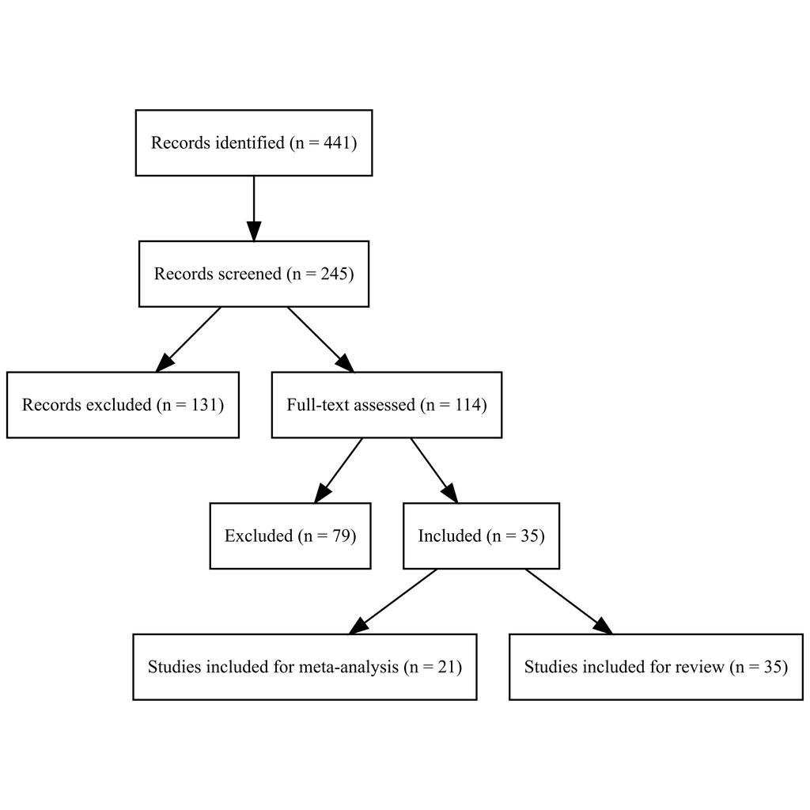

Figure 2

Meta-analytical associations between the five SEB domains and academic achievement.

[figure not shown]

Figure 3

Pooled correlation matrix

[figure not shown]